# Fat Bloom

Danilo Cillario

2018-01-21

In this section we collect some function to help the fat bloom analysis

## Function

**mosaicFB**: draw a mosaic plot of fat bloom vs month vs ‘cluster’ field

```
mosaicFB(dati, cluster='plant', filter=NULL, depivot=T, main='Affioramento prodotto', sub='')
```

**stackFB**:

```
stackFB(data, main='Titolo', new=c('mese', 'prodotto'), tabOnGraph=T)
```

**depivot**:

```
depivot(dati)
```

where:

[output not shown]

## Analysis data frame

The analysis data file for the function `stackFB()`, must contain the following field:

```
prodotto    :   identification of the product
mese        :   month of analysis
L1-L6       :   number of sample for each levels of fat bloom
```

as the following example **‘RO_OHG’**:

| prodotto | mese | L1 | L2 | L3 | L4 | L5 | L6 |
| --- | --- | --- | --- | --- | --- | --- | --- |
| TI5 | m1 | 64 | 0 | 0 | 0 | 0 | 0 |
| TI7 | m1 | 64 | 0 | 0 | 0 | 0 | 0 |
| TI5 | m2 | 62 | 0 | 0 | 1 | 1 | 0 |
| TI7 | m2 | 64 | 0 | 0 | 0 | 0 | 0 |
| TI5 | m3 | 35 | 21 | 4 | 0 | 3 | 1 |
| TI7 | m3 | 46 | 15 | 0 | 0 | 1 | 1 |

The analysis data file for the function `mosaicFB` (with option depivot=T), must contain the following field:

```
plant        :   test label (used in the legend)
mese         :   month of analysis
linea        :   line of production
L1-L6        :   number of sample for each levels of fat bloom
```

as the following example **‘RO_ALL’**:

| plant | mese | linea | L1 | L2 | L3 | L4 | L5 | L6 |
| --- | --- | --- | --- | --- | --- | --- | --- | --- |
| Alba | 1m | L4 | 15 | 1 | 0 | 0 | 0 | 0 |
| Alba | 1m | L4 | 7 | 9 | 0 | 0 | 0 | 0 |
| Alba | 1m | L1 | 16 | 0 | 0 | 0 | 0 | 0 |
| Alba | 1m | L2 | 10 | 6 | 0 | 0 | 0 | 0 |
| Alba | 1m | L4 | 14 | 2 | 0 | 0 | 0 | 0 |
| Alba | 1m | - | 16 | 0 | 0 | 0 | 0 | 0 |

The analysis data file the function `mosaicFB` (already depivoted), must contain the following field:

```
plant        :   test label (used in the legend)
mese         :   month of analysis
linea        :   line of production
affioramento :   level of fat bloom (from 1 to 6) of the praline
```

as the following example **‘RO_ALL_DE’**:

| plant | mese | linea | affioramento |
| --- | --- | --- | --- |
| Alba | 1m | L4 | 1 |
| Alba | 1m | L4 | 1 |
| Alba | 1m | L4 | 1 |
| Alba | 1m | L4 | 1 |
| Alba | 1m | L4 | 1 |
| Alba | 1m | L4 | 1 |

These data are calculated as:

```
RO_ALL_DE <- depivot(RO_ALL)
```

## Examples

### mosaic(FB)

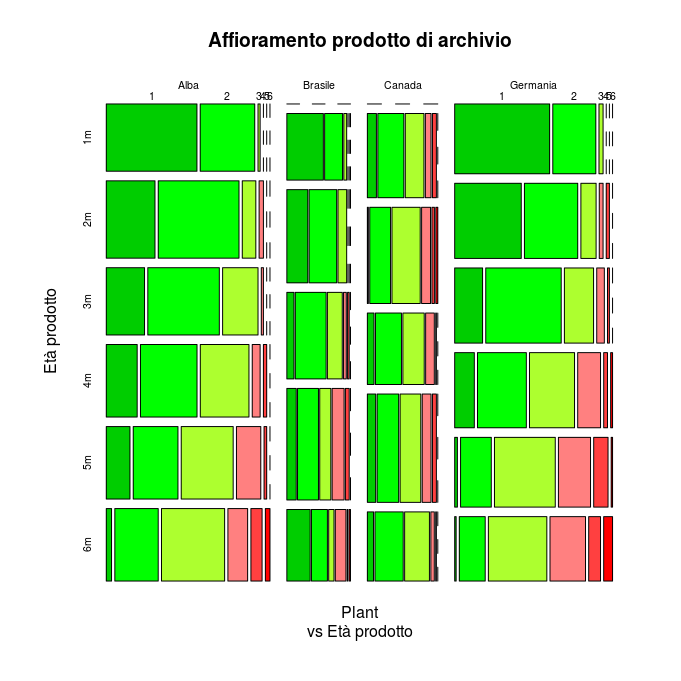

```r
library(tecTools)
data('RO_ALL')
mosaicFB(RO_ALL, depivot=T)
```

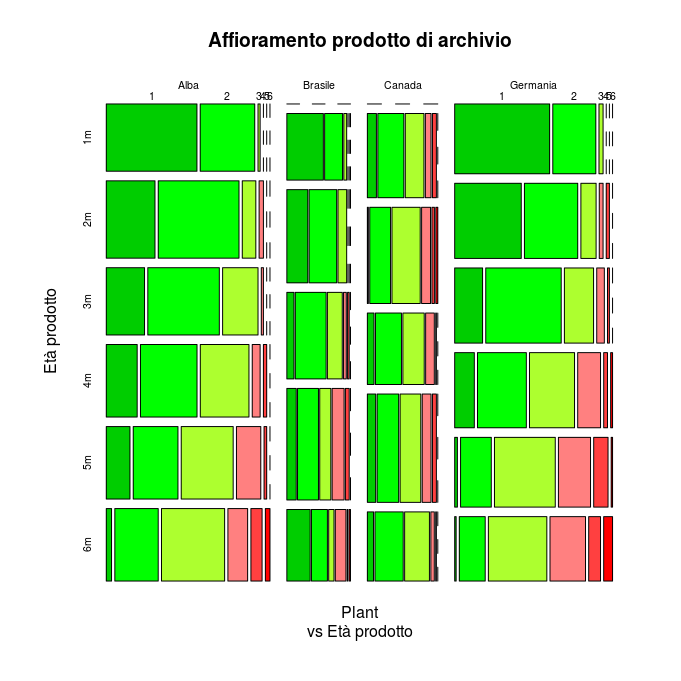

```r
library(tecTools)
data('RO_ALL_DE')
mosaicFB(RO_ALL_DE, depivot=F)
```

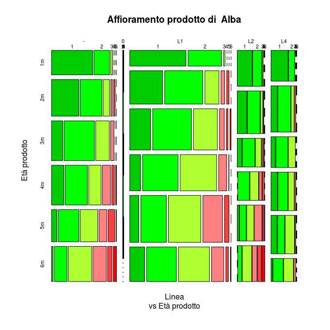

```r
library(tecTools)
data('RO_ALL_DE')
mosaicFB(RO_ALL_DE, tipo='Alba', depivot=F)
```

### stackFB()

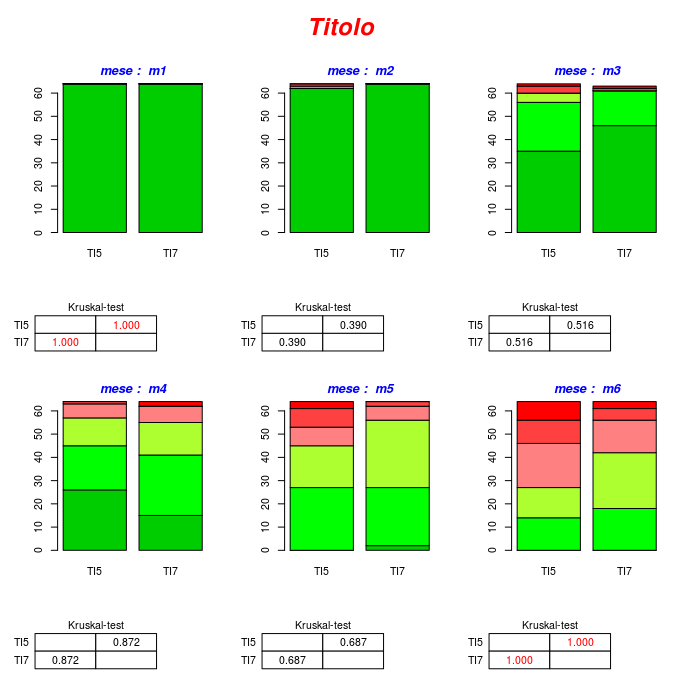

```r
library(tecTools)
data('RO_OHG')
stackFB(RO_OHG)
```

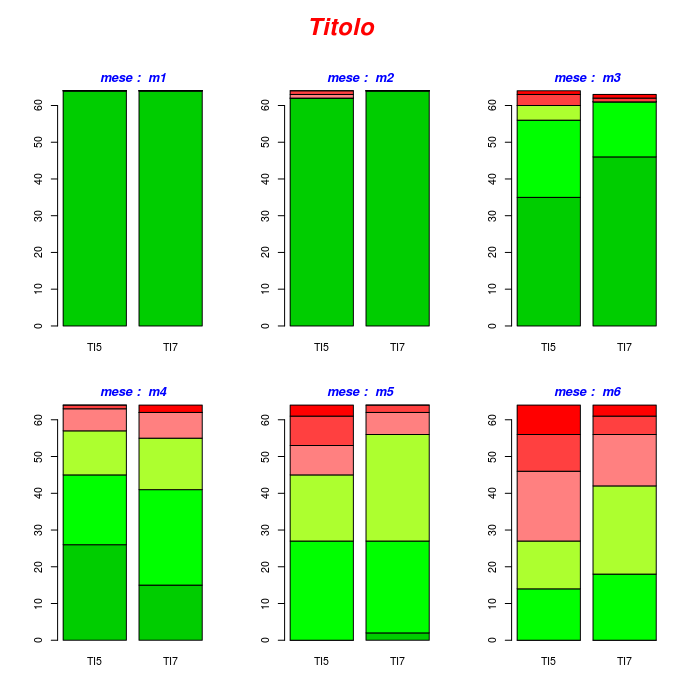

```r
library(tecTools)
data('RO_OHG')
stackFB(RO_OHG, tabOnGraph=F)
```

with graph for products

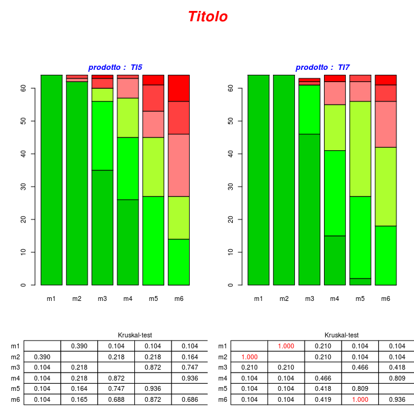

```r
library(tecTools)
data('RO_OHG')
stackFB(RO_OHG, new='prodotto')
```

## Reference

Immagini della scala dei livelli di affioramento

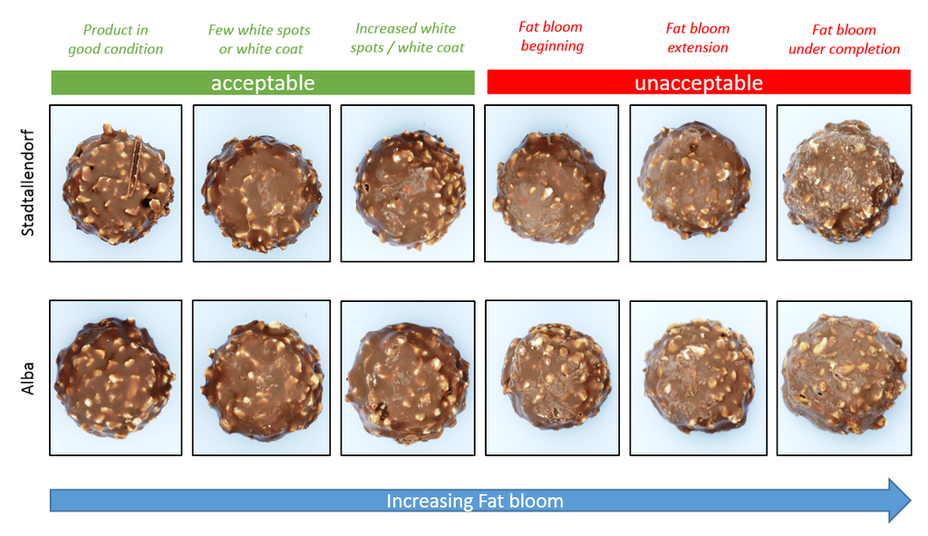

Onset calculation